# Borough Level Analysis: Exploring Interactions

Maya Arnott

## 1. Data Prepration

#### Prepare the variables

```r
asthma_precip_pm25 <- asthma_precip_pm25 |>
  mutate(
    date        = as.Date(date),
    borough     = as.factor(borough),
    year        = as.factor(year(date)),
    day_of_week = factor(wday(date, label = TRUE), ordered = FALSE),
    season      = as.factor(case_when(
      month(date) %in% c(12, 1, 2)  ~ "Winter",
      month(date) %in% c(3, 4, 5)   ~ "Spring",
      month(date) %in% c(6, 7, 8)   ~ "Summer",
      month(date) %in% c(9, 10, 11) ~ "Fall"
    ))
  )

# create log transformed ppt and pm25 var
asthma_precip_pm25 <- asthma_precip_pm25 |>
  mutate(
    log_ppt = log(ppt + 1)
  )

asthma_precip_pm25 <- asthma_precip_pm25 |>
  mutate(
    pm25 = if_else(pm25 < 0, 0, pm25),
    log_pm25 = log(pm25 + 1)
  )

# create thresholds for ppt
asthma_precip_pm25 <- asthma_precip_pm25 |>
  mutate(ppt_cat = case_when(
    ppt == 0        ~ "none",
    ppt < 1         ~ "trace",
    ppt < 10        ~ "light",
    ppt < 25        ~ "moderate",
    ppt >= 25       ~ "heavy"
  ) |> factor(levels = c("none", "trace", "light", "moderate", "heavy")))
```

An offset population variable was created because the raw counts can be misleading. Data was obtained from the`tidycensus` package.

```r
census_api_key(Sys.getenv("CENSUS_API_KEY"), overwrite = TRUE)
```

```
## To install your API key for use in future sessions, run this function with `install = TRUE`.
```

```r
# pop for years 2016 to 2019
years <- c(2016, 2017, 2018, 2019)

borough_pop <- purrr::map_dfr(years, ~{
  get_acs(
    geography = "county",
    variables = "B01003_001",  # total population estimate
    state     = "NY",
    county    = c("New York", "Kings", "Queens", "Bronx", "Richmond"),
    year      = .x
  ) |>
    mutate(year = as.character(.x))
}) |>
  mutate(borough = case_when(
    grepl("New York County", NAME)  ~ "Manhattan",
    grepl("Kings County", NAME)     ~ "Brooklyn",
    grepl("Queens County", NAME)    ~ "Queens",
    grepl("Bronx County", NAME)     ~ "Bronx",
    grepl("Richmond County", NAME)  ~ "Staten Island"
  )) |>
  select(borough, year, population = estimate)
# merge with other data
asthma_precip_pm25 <- asthma_precip_pm25 |>
  left_join(borough_pop, by = c("borough", "year"))
```

Temperature is likely a confounder in this relationship, and should be added to the model. Through NOAA, there is only data available from one weather station in Central Park, so the assumption is that the temperature across boroughs is fairly similar.

```r
temp_daily <- read_csv("datasets/daily_temp_nyc.csv") |>
  mutate(
    date     = as.Date(DATE),
    temp_avg = (TMAX + TMIN) / 2
  ) |>
  select(date, temp_avg)
asthma_precip_pm25 <- asthma_precip_pm25 |>
  left_join(temp_daily, by = "date")
```

#### Scale variables

`log_ppt` and `temperature` are scaled because this helps models converge and makes coefficients across covariates comparable. `log_pm25` is scaled here as well for use in the PM2.5-adjusted sensitivity analysis only. It is excluded from the main models because PM2.5 is a likely mediator on the causal pathway (precipitation washes particulate matter from the air, so adjusting for it in the primary model would constitute over-adjustment).

```r
asthma_precip_pm25 <- asthma_precip_pm25 |>
  mutate(
    log_ppt_scaled  = as.numeric(scale(log_ppt)),
    log_pm25_scaled = as.numeric(scale(log_pm25)),
    temp_scaled     = as.numeric(scale(temp_avg))
  )
```

## 2. Negative Binomial Model over Poisson

```r
# poisson
pois.model <- glm(
  asthma_er_count ~ log_ppt_scaled + temp_scaled + borough + season +
    day_of_week + year + offset(log(population)),
  family = poisson(link = "log"),
  data = asthma_precip_pm25
)

dispersiontest(pois.model)
```

```
##
##  Overdispersion test
##
## data:  pois.model
## z = 25.878, p-value < 2.2e-16
## alternative hypothesis: true dispersion is greater than 1
## sample estimates:
## dispersion
##   2.194335
```

According to the overdispersion test, there is evidence of significant overdispersion (dispersion = 2.20, p<.001), which justifies the use of a negative binomial model.

## 3. ICC

```r
# how much do daily visits cluster within borough?
asthma_precip_pm25 <- asthma_precip_pm25 |>
  mutate(asthma_rate = (asthma_er_count / population) * 100000)

asthma.ICC <- ICCest(borough, asthma_rate, data = asthma_precip_pm25)
asthma.ICC$ICC
```

```
## [1] 0.6802938
```

```r
asthma.ICC$LowerCI
```

```
## [1] 0.4327528
```

```r
asthma.ICC$UpperCI
```

```
## [1] 0.946171
```

```r
# how much does rain cluster within borough?
ppt.ICC <- ICCest(borough, log_ppt_scaled, data = asthma_precip_pm25)
ppt.ICC$ICC
```

```
## [1] -0.0006795941
```

#### ICC Results Table

```r
icc_table <- data.frame(
  Variable      = c("Asthma ED Visit Rate (per 100,000)", "Log Precipitation (scaled)"),
  ICC           = c(round(asthma.ICC$ICC, 3), round(ppt.ICC$ICC, 3)),
  Lower_CI      = c(round(asthma.ICC$LowerCI, 3), NA),
  Upper_CI      = c(round(asthma.ICC$UpperCI, 3), NA),
  Interpretation = c(
    "68% of variation is between boroughs",
    "No borough-level clustering"
  )
)

icc_table |>
  gt() |>
  cols_label(
    Variable       = "Variable",
    ICC            = "ICC",
    Lower_CI       = "95% CI Lower",
    Upper_CI       = "95% CI Upper",
    Interpretation = "Interpretation"
  ) |>
  tab_header(title = "Table 1. Intraclass Correlation Coefficients by Borough")
```

Table 1. Intraclass Correlation Coefficients by Borough

| Variable | ICC | 95% CI Lower | 95% CI Upper | Interpretation |
| --- | --- | --- | --- | --- |
| Asthma ED Visit Rate (per 100,000) | 0.680 | 0.433 | 0.946 | 68% of variation is between boroughs |
| Log Precipitation (scaled) | -0.001 | NA | NA | No borough-level clustering |

Asthma Rate ICC = 0.68. 68% of the total variation in daily asthma ED visit rates is attributable to between-borough differences, whereas only 32% is day-to-day within-borough variation. This justifies including borough fixed intercepts.

Precipitation ICC = -0.001. This means that precipitation is not confounded by borough and the variation in rain is only temporal.

## 4. Between borough model (ecological)

```r
dta_btwn <- asthma_precip_pm25 |>
  group_by(borough) |>
  summarize(
    mean_asthma_rate = mean(asthma_rate, na.rm = TRUE),
    mean_log_ppt     = mean(log_ppt_scaled, na.rm = TRUE),
    .groups = "drop"
  )

mod.btwn <- lm(
  mean_asthma_rate ~ mean_log_ppt,
  data = dta_btwn
)

summary(mod.btwn)
```

```
##
## Call:
## lm(formula = mean_asthma_rate ~ mean_log_ppt, data = dta_btwn)
##
## Residuals:
##       1       2       3       4       5
##  1.3120  1.1485 -0.7827 -1.0632 -0.6145
##
## Coefficients:
##              Estimate Std. Error t value Pr(>|t|)
## (Intercept)    3.1772     0.5866   5.417   0.0123 *
## mean_log_ppt 216.5140   217.3524   0.996   0.3926
## ---
## Signif. codes:  0 '***' 0.001 '**' 0.01 '*' 0.05 '.' 0.1 ' ' 1
##
## Residual standard error: 1.312 on 3 degrees of freedom
## Multiple R-squared:  0.2486, Adjusted R-squared:  -0.001929
## F-statistic: 0.9923 on 1 and 3 DF,  p-value: 0.3926
```

## 5. Main Model: Borough Fixed Intercepts (no interactions)

```r
mod.fixed <- glm.nb(
  asthma_er_count ~ log_ppt_scaled + temp_scaled + borough +
    season + day_of_week + year + offset(log(population)),
  data = asthma_precip_pm25
)

# model outputs
summary(mod.fixed)
```

```
##
## Call:
## glm.nb(formula = asthma_er_count ~ log_ppt_scaled + temp_scaled +
##     borough + season + day_of_week + year + offset(log(population)),
##     data = asthma_precip_pm25, init.theta = 44.62242886, link = log)
##
## Coefficients:
##                       Estimate Std. Error  z value Pr(>|z|)
## (Intercept)          -9.860266   0.010041 -982.025  < 2e-16 ***
## log_ppt_scaled       -0.007005   0.002522   -2.778 0.005478 **
## temp_scaled           0.012517   0.004102    3.052 0.002276 **
## boroughBrooklyn      -0.379167   0.006920  -54.790  < 2e-16 ***
## boroughManhattan     -0.608364   0.007448  -81.676  < 2e-16 ***
## boroughQueens        -1.201777   0.007732 -155.428  < 2e-16 ***
## boroughStaten Island -0.562729   0.009497  -59.254  < 2e-16 ***
## seasonSpring          0.026149   0.007072    3.697 0.000218 ***
## seasonSummer         -0.258454   0.008190  -31.556  < 2e-16 ***
## seasonWinter         -0.027452   0.008755   -3.136 0.001715 **
## day_of_weekMon        0.198473   0.009260   21.433  < 2e-16 ***
## day_of_weekTue        0.125903   0.009342   13.477  < 2e-16 ***
## day_of_weekWed        0.092831   0.009379    9.898  < 2e-16 ***
## day_of_weekThu        0.050784   0.009425    5.388 7.11e-08 ***
## day_of_weekFri        0.013791   0.009451    1.459 0.144484
## day_of_weekSat       -0.076426   0.009554   -8.000 1.25e-15 ***
## year2017             -0.052992   0.007050   -7.517 5.62e-14 ***
## year2018              0.001409   0.007042    0.200 0.841425
## year2019             -0.034847   0.007102   -4.907 9.27e-07 ***
## ---
## Signif. codes:  0 '***' 0.001 '**' 0.01 '*' 0.05 '.' 0.1 ' ' 1
##
## (Dispersion parameter for Negative Binomial(44.6224) family taken to be 1)
##
##     Null deviance: 36465.9  on 7264  degrees of freedom
## Residual deviance:  7592.1  on 7246  degrees of freedom
## AIC: 53380
##
## Number of Fisher Scoring iterations: 1
##
##
##               Theta:  44.62
##           Std. Err.:  1.46
##
##  2 x log-likelihood:  -53339.86
```

```r
beta_ppt <- summary(mod.fixed)$coefficients["log_ppt_scaled", "Estimate"]
se_ppt   <- summary(mod.fixed)$coefficients["log_ppt_scaled", "Std. Error"]
lci_ppt  <- beta_ppt - 1.96 * se_ppt
uci_ppt  <- beta_ppt + 1.96 * se_ppt

rr_ppt <- paste0(
  round(exp(beta_ppt), 3), " (95% CI: ",
  round(exp(lci_ppt), 3), ", ",
  round(exp(uci_ppt), 3), ")"
)
rr_ppt
```

```
## [1] "0.993 (95% CI: 0.988, 0.998)"
```

#### Main Model Results Table

```r
mod.fixed |>
  tidy(conf.int = TRUE, exponentiate = TRUE) |>
  filter(!str_detect(term, "day_of_week")) |>
  mutate(
    term = case_when(
      term == "(Intercept)"          ~ "Intercept",
      term == "log_ppt_scaled"       ~ "Log Precipitation (1 SD)",
      term == "temp_scaled"          ~ "Temperature (1 SD)",
      term == "boroughBrooklyn"      ~ "Borough: Brooklyn vs Bronx",
      term == "boroughManhattan"     ~ "Borough: Manhattan vs Bronx",
      term == "boroughQueens"        ~ "Borough: Queens vs Bronx",
      term == "boroughStaten Island" ~ "Borough: Staten Island vs Bronx",
      term == "seasonSpring"         ~ "Season: Spring vs Fall",
      term == "seasonSummer"         ~ "Season: Summer vs Fall",
      term == "seasonWinter"         ~ "Season: Winter vs Fall",
      term == "year2017"             ~ "Year: 2017 vs 2016",
      term == "year2018"             ~ "Year: 2018 vs 2016",
      term == "year2019"             ~ "Year: 2019 vs 2016",
      TRUE ~ term
    )
  ) |>
  select(term, estimate, conf.low, conf.high, p.value) |>
  gt() |>
  cols_label(
    term      = "Variable",
    estimate  = "Rate Ratio",
    conf.low  = "95% CI Lower",
    conf.high = "95% CI Upper",
    p.value   = "p-value"
  ) |>
  fmt_number(columns = c(estimate, conf.low, conf.high), decimals = 3) |>
  fmt(columns = p.value, fns = function(x) ifelse(x < 0.001, "<0.001", round(x, 3))) |>
  tab_header(title = "Table 2. Borough Fixed Intercept Negative Binomial Model") |>
  tab_footnote("Rate ratios and 95% CIs shown. Reference categories: Bronx (borough), Fall (season), 2016 (year). Offset = log(population).")
```

Table 2. Borough Fixed Intercept Negative Binomial Model

| Variable | Rate Ratio | 95% CI Lower | 95% CI Upper | p-value |
| --- | --- | --- | --- | --- |
| Intercept | 0.000 | 0.000 | 0.000 | <0.001 |
| Log Precipitation (1 SD) | 0.993 | 0.988 | 0.998 | 0.005 |
| Temperature (1 SD) | 1.013 | 1.004 | 1.021 | 0.002 |
| Borough: Brooklyn vs Bronx | 0.684 | 0.675 | 0.694 | <0.001 |
| Borough: Manhattan vs Bronx | 0.544 | 0.536 | 0.552 | <0.001 |
| Borough: Queens vs Bronx | 0.301 | 0.296 | 0.305 | <0.001 |
| Borough: Staten Island vs Bronx | 0.570 | 0.559 | 0.580 | <0.001 |
| Season: Spring vs Fall | 1.026 | 1.012 | 1.041 | <0.001 |
| Season: Summer vs Fall | 0.772 | 0.760 | 0.785 | <0.001 |
| Season: Winter vs Fall | 0.973 | 0.956 | 0.990 | 0.002 |
| Year: 2017 vs 2016 | 0.948 | 0.935 | 0.962 | <0.001 |
| Year: 2018 vs 2016 | 1.001 | 0.988 | 1.015 | 0.841 |
| Year: 2019 vs 2016 | 0.966 | 0.952 | 0.979 | <0.001 |

Rate ratios and 95% CIs shown. Reference categories: Bronx (borough), Fall (season), 2016 (year). Offset = log(population).

#### Fixed Intercept Coefficient Plot

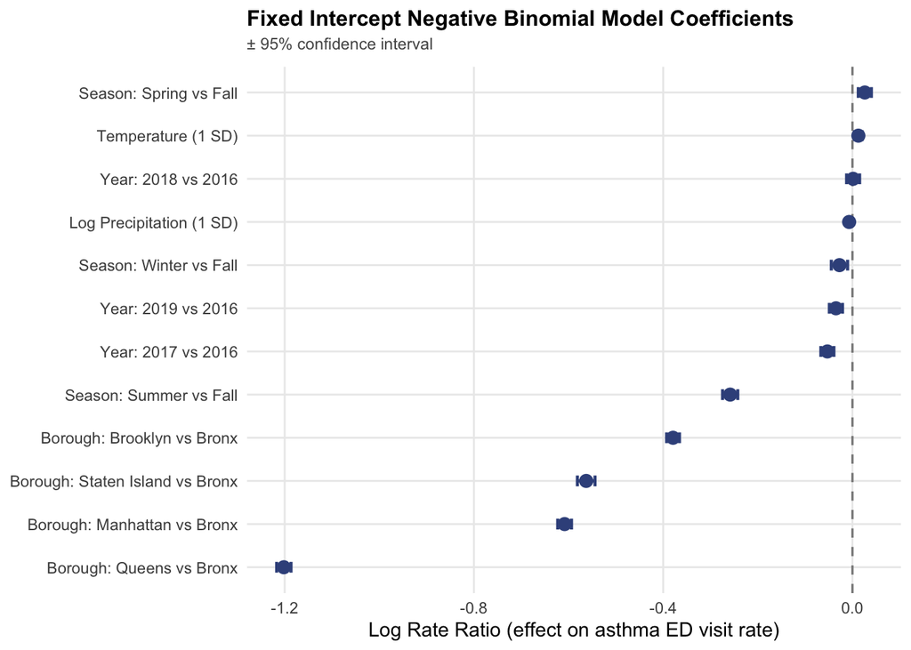

```r
coef_plot_df <- mod.fixed |>
  tidy(conf.int = TRUE, exponentiate = FALSE) |>  # keep on log scale for plot
  filter(term != "(Intercept)") |>
  filter(!str_detect(term, "day_of_week")) |>
  mutate(term = case_when(
    term == "log_ppt_scaled"            ~ "Log Precipitation (1 SD)",
    term == "temp_scaled"               ~ "Temperature (1 SD)",
    term == "boroughBrooklyn"           ~ "Borough: Brooklyn vs Bronx",
    term == "boroughManhattan"          ~ "Borough: Manhattan vs Bronx",
    term == "boroughQueens"             ~ "Borough: Queens vs Bronx",
    term == "boroughStaten Island"      ~ "Borough: Staten Island vs Bronx",
    term == "seasonSpring"              ~ "Season: Spring vs Fall",
    term == "seasonSummer"              ~ "Season: Summer vs Fall",
    term == "seasonWinter"              ~ "Season: Winter vs Fall",
    term == "year2017"                  ~ "Year: 2017 vs 2016",
    term == "year2018"                  ~ "Year: 2018 vs 2016",
    term == "year2019"                  ~ "Year: 2019 vs 2016",
    TRUE ~ term
  ))

ggplot(coef_plot_df, aes(x = estimate, y = reorder(term, estimate))) +
  geom_vline(
    xintercept = 0,
    linetype   = "dashed",
    color      = "grey55",
    linewidth  = 0.6
  ) +
  geom_errorbarh(
    aes(xmin = conf.low, xmax = conf.high),
    width     = 0.25,
    linewidth = 0.8,
    color     = "#3B528B"
  ) +
  geom_point(color = "#3B528B", size = 3) +
  labs(
    title    = "Fixed Intercept Negative Binomial Model Coefficients",
    subtitle = "± 95% confidence interval",
    x        = "Log Rate Ratio (effect on asthma ED visit rate)",
    y        = NULL
  ) +
  theme_minimal(base_size = 11) +
  theme(
    plot.title       = element_text(face = "bold", size = 12, margin = margin(b = 4)),
    plot.subtitle    = element_text(size = 9, color = "#555555", lineheight = 1.3, margin = margin(b = 8)),
    panel.grid.minor = element_blank()
  )
```

```r
# save plot as png
ggsave(
  filename = "outputs/coef_plot_fixed_intercept.png",
  plot     = last_plot(),
  width    = 8,
  height   = 6,
  dpi      = 300
)
```

**`log_ppt_scaled`** A 1 SD increase in log precipitation is associated with a 0.7% decrease in asthma ED visit rates (RR = 0.993, 95% CI: 0.988–0.998, p = 0.005). The direction is negative — rain may reduce same-day asthma burden by washing PM2.5 and ozone from the air. The effect is statistically significant but small in magnitude.

**`borough`** All boroughs had significantly lower asthma ED visit rates than the Bronx (all p < 0.001). Rate ratios: Brooklyn 0.68, Manhattan 0.54, Queens 0.30, Staten Island 0.57. The Bronx’s dominant baseline is consistent with documented asthma burden disparities driven by housing quality, green space, and pollution exposure.

**`season`** Spring was slightly elevated relative to Fall (RR = 1.03, p < 0.001), consistent with allergy season overlap. Summer was protective (RR = 0.77, p < 0.001) even after adjusting for temperature, suggesting seasonal factors beyond heat. Winter was modestly lower than Fall (RR = 0.97, p = 0.002).

#### Marginal Effects plot

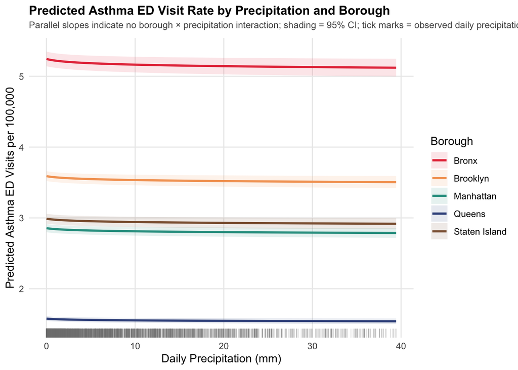

```r
# scale parameters for back-transformation to mm
log_ppt_mean <- mean(asthma_precip_pm25$log_ppt, na.rm = TRUE)
log_ppt_sd   <- sd(asthma_precip_pm25$log_ppt, na.rm = TRUE)

# clip at 99th percentile
ppt_cap <- quantile(asthma_precip_pm25$ppt, 0.99, na.rm = TRUE)
ppt_seq <- seq(
  min(asthma_precip_pm25$log_ppt_scaled, na.rm = TRUE),
  (log(ppt_cap + 1) - log_ppt_mean) / log_ppt_sd,
  length.out = 200
)

# compute predictions directly from model coefficients + vcov (delta method)
# population offset cancels when converting count to rate
coefs <- coef(mod.fixed)
vc    <- vcov(mod.fixed)

borough_terms <- c(
  "Bronx"         = NA,
  "Brooklyn"      = "boroughBrooklyn",
  "Manhattan"     = "boroughManhattan",
  "Queens"        = "boroughQueens",
  "Staten Island" = "boroughStaten Island"
)

marg_preds <- purrr::map_dfr(names(borough_terms), function(bor) {
  bor_term <- borough_terms[bor]
  if (is.na(bor_term)) {
    terms <- c("(Intercept)", "log_ppt_scaled")
    W     <- cbind(1, ppt_seq)
  } else {
    terms <- c("(Intercept)", bor_term, "log_ppt_scaled")
    W     <- cbind(1, 1, ppt_seq)
  }
  lp    <- as.numeric(W %*% coefs[terms])
  se_lp <- sqrt(diag(W %*% vc[terms, terms] %*% t(W)))
  data.frame(
    borough  = bor,
    ppt_mm   = exp(ppt_seq * log_ppt_sd + log_ppt_mean) - 1,
    rate     = 100000 * exp(lp),
    rate_low = 100000 * exp(lp - 1.96 * se_lp),
    rate_hi  = 100000 * exp(lp + 1.96 * se_lp)
  )
})

# observed precipitation for tick marks on plot
ppt_obs <- asthma_precip_pm25 |>
  distinct(date, ppt) |>
  filter(ppt <= ppt_cap)

borough_colors <- c(
  "Bronx"         = "#E63946",
  "Brooklyn"      = "#F4A261",
  "Manhattan"     = "#2A9D8F",
  "Queens"        = "#3B528B",
  "Staten Island" = "#8B5E3C"
)

ggplot(marg_preds, aes(x = ppt_mm, y = rate, color = borough, fill = borough)) +
  geom_ribbon(aes(ymin = rate_low, ymax = rate_hi), alpha = 0.12, color = NA) +
  geom_line(linewidth = 1) +
  geom_rug(
    data        = ppt_obs,
    aes(x = ppt),
    inherit.aes = FALSE,
    color       = "grey50",
    alpha       = 0.3,
    linewidth   = 0.3,
    sides       = "b"
  ) +
  scale_color_manual(values = borough_colors) +
  scale_fill_manual(values = borough_colors) +
  coord_cartesian(xlim = c(0, ppt_cap)) +
  labs(
    title    = "Predicted Asthma ED Visit Rate by Precipitation and Borough",
    subtitle = "Parallel slopes indicate no borough × precipitation interaction; shading = 95% CI; tick marks = observed daily precipitation; x-axis capped at 99th percentile",
    x        = "Daily Precipitation (mm)",
    y        = "Predicted Asthma ED Visits per 100,000",
    color    = "Borough",
    fill     = "Borough"
  ) +
  theme_minimal(base_size = 11) +
  theme(
    plot.title       = element_text(face = "bold", size = 12, margin = margin(b = 4)),
    plot.subtitle    = element_text(size = 9, color = "#555555", lineheight = 1.3, margin = margin(b = 8)),
    panel.grid.minor = element_blank(),
    legend.position  = "right"
  )
```

```r
ggsave(
  filename = "outputs/marginal_effects_ppt_by_borough.png",
  plot     = last_plot(),
  width    = 9,
  height   = 5,
  dpi      = 300
)
```

## 6. Effect Modification - Borough Interaction

```r
# reduced model (as noted earlier)
mod.fixed <- glm.nb(
  asthma_er_count ~ log_ppt_scaled + temp_scaled + borough +
    season + day_of_week + year + offset(log(population)),
  data = asthma_precip_pm25
)

# full model with interaction
mod.full <- glm.nb(
  asthma_er_count ~ log_ppt_scaled * borough + temp_scaled +
    season + day_of_week + year + offset(log(population)),
  data = asthma_precip_pm25
)

# likelihood ratio test
lrtest(mod.fixed, mod.full)
```

```
## Likelihood ratio test
##
## Model 1: asthma_er_count ~ log_ppt_scaled + temp_scaled + borough + season +
##     day_of_week + year + offset(log(population))
## Model 2: asthma_er_count ~ log_ppt_scaled * borough + temp_scaled + season +
##     day_of_week + year + offset(log(population))
##   #Df LogLik Df  Chisq Pr(>Chisq)
## 1  20 -26670
## 2  24 -26669  4 2.6239     0.6226
```

```r
# anova test
Anova(mod.full, type = "III")
```

```
## Analysis of Deviance Table (Type III tests)
##
## Response: asthma_er_count
##                        LR Chisq Df Pr(>Chisq)
## log_ppt_scaled              0.4  1   0.518352
## borough                 25645.5  4  < 2.2e-16 ***
## temp_scaled                 9.2  1   0.002392 **
## season                   1336.2  3  < 2.2e-16 ***
## day_of_week              1128.4  6  < 2.2e-16 ***
## year                       86.6  3  < 2.2e-16 ***
## log_ppt_scaled:borough      2.6  4   0.622510
## ---
## Signif. codes:  0 '***' 0.001 '**' 0.01 '*' 0.05 '.' 0.1 ' ' 1
```

## 7. Sensitivity Analyses

### 7a. PM2.5-Adjusted Sensitivity Analysis

PM2.5 is excluded from the primary models because it is a likely mediator (precipitation washes particulate matter from the air, so adjusting for it would block part of the causal mechanism and produce over-adjustment bias). This sensitivity analysis adds `log_pm25_scaled` to assess how much the precipitation estimate changes.

```r
# PM2.5-adjusted fixed intercept model
mod.pm25 <- glm.nb(
  asthma_er_count ~ log_ppt_scaled + log_pm25_scaled + temp_scaled + borough +
    season + day_of_week + year + offset(log(population)),
  data = asthma_precip_pm25
)

summary(mod.pm25)
```

```
##
## Call:
## glm.nb(formula = asthma_er_count ~ log_ppt_scaled + log_pm25_scaled +
##     temp_scaled + borough + season + day_of_week + year + offset(log(population)),
##     data = asthma_precip_pm25, init.theta = 44.59235404, link = log)
##
## Coefficients:
##                       Estimate Std. Error  z value Pr(>|z|)
## (Intercept)          -9.863016   0.010220 -965.061  < 2e-16 ***
## log_ppt_scaled       -0.008003   0.002622   -3.052 0.002270 **
## log_pm25_scaled      -0.003330   0.002858   -1.165 0.243934
## temp_scaled           0.013729   0.004221    3.253 0.001144 **
## boroughBrooklyn      -0.379184   0.006953  -54.532  < 2e-16 ***
## boroughManhattan     -0.607396   0.007507  -80.908  < 2e-16 ***
## boroughQueens        -1.201896   0.007734 -155.395  < 2e-16 ***
## boroughStaten Island -0.563049   0.009513  -59.187  < 2e-16 ***
## seasonSpring          0.026852   0.007101    3.782 0.000156 ***
## seasonSummer         -0.257860   0.008223  -31.357  < 2e-16 ***
## seasonWinter         -0.023033   0.009551   -2.412 0.015880 *
## day_of_weekMon        0.199892   0.009301   21.492  < 2e-16 ***
## day_of_weekTue        0.127362   0.009380   13.578  < 2e-16 ***
## day_of_weekWed        0.094275   0.009441    9.986  < 2e-16 ***
## day_of_weekThu        0.052010   0.009473    5.490 4.01e-08 ***
## day_of_weekFri        0.014778   0.009488    1.558 0.119350
## day_of_weekSat       -0.075666   0.009575   -7.902 2.74e-15 ***
## year2017             -0.052437   0.007079   -7.408 1.28e-13 ***
## year2018              0.001571   0.007048    0.223 0.823593
## year2019             -0.034848   0.007105   -4.905 9.34e-07 ***
## ---
## Signif. codes:  0 '***' 0.001 '**' 0.01 '*' 0.05 '.' 0.1 ' ' 1
##
## (Dispersion parameter for Negative Binomial(44.5924) family taken to be 1)
##
##     Null deviance: 36417  on 7238  degrees of freedom
## Residual deviance:  7565  on 7219  degrees of freedom
##   (26 observations deleted due to missingness)
## AIC: 53183
##
## Number of Fisher Scoring iterations: 1
##
##
##               Theta:  44.59
##           Std. Err.:  1.46
##
##  2 x log-likelihood:  -53140.68
```

The precipitation estimate is essentially stable: RR = 0.992 (β = −0.008) compared to RR = 0.993 (β = −0.007) in the primary model. This is a negligible shift that confirms PM2.5 is neither confounding nor meaningfully mediating the precipitation-asthma relationship. The decision to exclude PM2.5 from the primary model is validated.

PM2.5 itself is not significantly associated with asthma ED visits after adjusting for season and temperature (β = −0.003, p = 0.244). The non-significant and counter-directional coefficient suggests that season and temperature already absorb most of the day-to-day PM2.5 variation, leaving little residual signal. Note that 26 observations were dropped due to PM2.5 missingness in this model.